# Infecções por *Klebsiella pneumoniae*

Damaris Krul, Libera Maria Dalla Costa e [Henrique Laureano](https://henriquelaureano.github.io/)

Last modification on* 2022-07-12 12:50:08

# Condição patológica

> Frequências (`n`) e respectivos percentuais.

```
# A tibble: 7 × 3
  `Prior pathological condition`     n  perc
  <chr>                          <int> <dbl>
1 Neurologic diseases               10  0.4
2 onco-hematological diseases        7  0.28
3 gastrointestinal diseases          3  0.12
4 Genetic disorders                  2  0.08
5 cardiac diseases                   1  0.04
6 Primary Immunodeficiency           1  0.04
7 Sd. de Prune Belly (congênita)     1  0.04
```

> Via Teste Qui-Quadrado, as frequências de condições patológicas diferem de maneira estatisticamente significativa com *p*-valor de 0.00242. Isso significa que temos evidências de que tais condições patológicas não aparecem de maneira equi-provável quando falamos de infecções por *Klebsiella pneumoniae*, algumas condições se mostram estatisticamente mais prováveis que outras.

> A significância encontrada pode provavelmente ser explicada pela comparação de frequências unitárias com a frequência 10. Quando selecionamos apenas condições patológicas com fequências > 1 e as comparamos, o *p*-valor obtido é de 0.07103, próximo do famoso limiar de 0.05.

# Hospitalização

```
# A tibble: 6 × 3
  `Hospital Unit`         n  perc
  <chr>               <int> <dbl>
1 ICU                    12  0.48
2 Emergency               4  0.16
3 General Clinic          4  0.16
4 Neurology               2  0.08
5 Onco-Hematology         2  0.08
6 Infectious Diseases     1  0.04
```

> Via Teste Qui-Quadrado, as frequências de tipos de hospitalização diferem estatisticamente com *p*-valor de 0.0024, i.e. temos evidências de que elas não são equi-prováveis.

> Quando consideramos apenas os tipos de hospitalização com frequência percentual superior à 10%, a diferença das frequências ainda é significativa (*p*-valor de 0.04687). Ou seja, temos evidência estatística de que o tipo de hospitalização mais frequente é a UTI (`ICU`).

# Sexo, idade e hospitalização (tempo)

```
# A tibble: 2 × 3
  Gender     n  perc
  <chr>  <int> <dbl>
1 F         11  0.44
2 M         14  0.56
```

> Via Teste Qui-Quadrado, o número de pacientes do sexo feminino não difere do número de pacientes do sexo masculino (*p*-valor de 0.54851).

> As idades dos pacientes, em meses, são descritas em termos das seguintes medidas-resumo: mínimo; primeiro quartil (que divide em 25% - 75%); mediana (50% - 50%); média; terceito quartil (75% - 25%); máximo; desvio-padrão, respectivamente.

```
# A tibble: 1 × 7
   Min. `1st Qu.` Median  Mean `3rd Qu.`  Max.    SD
  <dbl>     <dbl>  <dbl> <dbl>     <dbl> <dbl> <dbl>
1     2         5     12  47.5        84   192  57.9
```

> Medidas-resumo das idades por sexo.

```
# A tibble: 2 × 8
  Gender  Min. `1st Qu.` Median  Mean `3rd Qu.`   Max    SD
  <chr>  <dbl>     <dbl>  <dbl> <dbl>     <dbl> <dbl> <dbl>
1 F          2      10.5     12  40.6        78   120  45.6
2 M          4       5        8  52.9        99   192  67.2
```

> Via Teste-*t* podemos comparar a idade média dos pacientes do sexo feminino com a idade média dos pacientes do sexo masculino. A diferença média de idade é de 12.3 meses, não estatisticamente significativa (*p*-valor de 0.592).

```
# A tibble: 1 × 4
  estimate conf.low conf.high p.value
     <dbl>    <dbl>     <dbl>   <dbl>
1    -12.3    -59.1      34.5   0.592
```

> As medidas-resumo dos tempos de hospitalização dos pacientes, em meses, são apresentadas a seguir.

> (Para os pacientes com tempo de hospitalização inferior a 1 mês, foi utlizado o valor 0.5 (mês)).

```
# A tibble: 1 × 7
   Min. `1st Qu.` Median  Mean `3rd Qu.`  Max.    SD
  <dbl>     <dbl>  <dbl> <dbl>     <dbl> <dbl> <dbl>
1   0.5         1      2  2.36         3     8  1.85
```

> E estratificadas por sexo.

```
# A tibble: 2 × 8
  Gender  Min. `1st Qu.` Median  Mean `3rd Qu.`   Max    SD
  <chr>  <dbl>     <dbl>  <dbl> <dbl>     <dbl> <dbl> <dbl>
1 F        0.5     1          2  2.18      2        8  2.08
2 M        0.5     0.625      3  2.5       3.75     6  1.72
```

> Com *p*-valor de 0.687, a diferença média de 0.318 meses dos tempos de hospitalização entre sexos não é significativa.

```
# A tibble: 1 × 4
  estimate conf.low conf.high p.value
     <dbl>    <dbl>     <dbl>   <dbl>
1   -0.318    -1.94      1.31   0.687
```

## Correlações e relações

> Abaixo, cruzamos as idades com os tempos de hospitalização em termos de suas correlações lineares de *Pearson*.

> Nas linhas 2 à 5 da tabela as correlações são calculadas e testadas de maneira estratifica, definida na primeira coluna. Além do valor da correlação, são apresentados os limites inferiores e superiores de intervalos de 95% de confiança para as correlações; suas respectivas significâncias e tamanho amostral (para termos uma noção da representatividade).

```
# A tibble: 5 × 6
  `Age vs. Hospital Stay by` correlation conf.low conf.high p.value     n
  <chr>                            <dbl>    <dbl>     <dbl>   <dbl> <dbl>
1 Itself                          -0.475   -0.733   -0.0983 0.0164     25
2 Female gender                   -0.171   -0.699    0.478  0.615      11
3 Male gender                     -0.721   -0.905   -0.308  0.00363    14
4 Death clincal outcome           -0.609   -0.895    0.0333 0.0616     10
5 Recovery clincal outcome        -0.394   -0.754    0.148  0.146      15
```

> - Sem estratificar, a correlação (linear) idade vs. tempo de hospitalização é estatisticamente significativa (*p*-valor de 0.01643);
> - Estratificando pelo sexo feminino a correlação não é significativa (*p*-valor de 0.61461);
> - Estratificando pelo sexo masculino a correlação é significativa ( *p*-valor de 0.00363);
> - Estratificando pela mortalidade (`death`) a correlação não é significativa 0.06162;
> - Estratificando pela mortalidade (`recovery`) a correlação não é significativa 0.14572.

> Interessante destacar que todas as correlações são negativas, i.e. conforme se idade do paciente aumenta, o tempo de hospitalização diminuí.

> O problema de se olhar para a correlação baseada unicamente em coeficientes, é que podemos ser “enganados” por *outliers* ou não percebermos a existência de não-linearidade, já que a correlação pressupõem linearidade.

> A seguir, *plotamos* as idades pelos tempos de hospitalização. Por mais que possamos ajustar uma reta, fica claro que a função que melhor descreve o comportamento observado é uma curva quadrática. Vemos um padrão de decaímento e então crescimento.

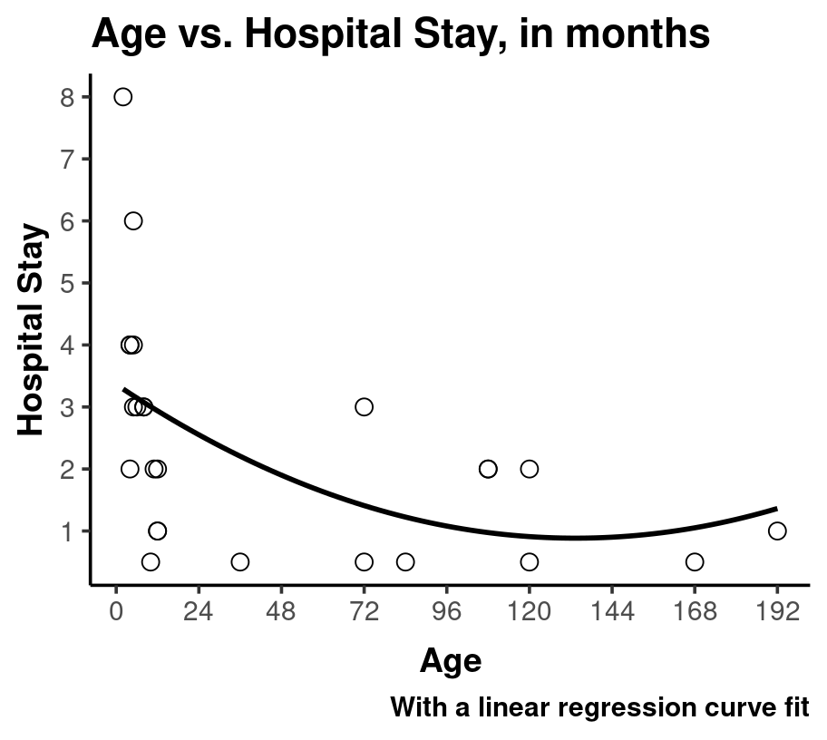

> Plotamos também fazendo a estratificação.

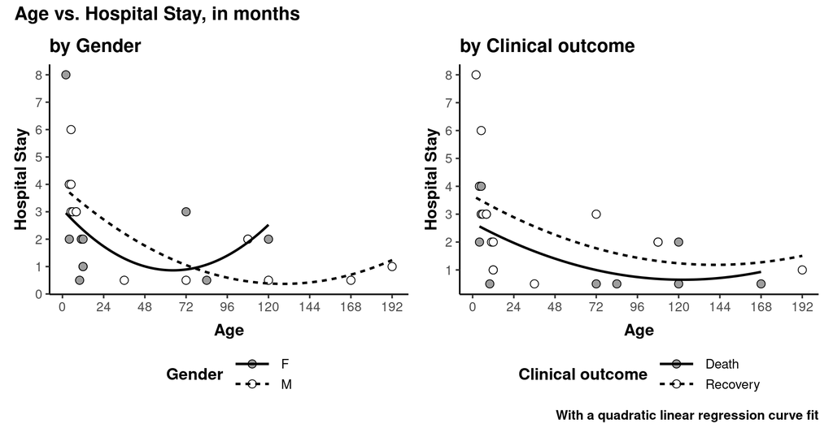

> Medidas-resumo das idades por mortalidade.

```
# A tibble: 2 × 8
  `Clinical outcome`  Min. `1st Qu.` Median  Mean `3rd Qu.`   Max    SD
  <chr>              <dbl>     <dbl>  <dbl> <dbl>     <dbl> <dbl> <dbl>
1 Death                  4      5.75     41  59.6       111   168  61.4
2 Recovery               2      5.5      12  39.5        54   192  56.1
```

> A diferença média de 20.1 meses não é estatisticamente significativa (*p*-valor de 0.417).

```
# A tibble: 1 × 4
  estimate conf.low conf.high p.value
     <dbl>    <dbl>     <dbl>   <dbl>
1     20.1    -30.7      71.0   0.417
```

> Medidas-resumo dos tempos de hospitalização por mortalidade.

```
# A tibble: 2 × 8
  `Clinical outcome`  Min. `1st Qu.` Median  Mean `3rd Qu.`   Max    SD
  <chr>              <dbl>     <dbl>  <dbl> <dbl>     <dbl> <dbl> <dbl>
1 Death                0.5       0.5   1.25  1.65      2.75     4  1.33
2 Recovery             0.5       1.5   2     2.83      3.5      8  2.03
```

> A diferença média de 1.18 meses não é estatisticamente significativa (*p*-valor de 0.0922).

```
# A tibble: 1 × 4
  estimate conf.low conf.high p.value
     <dbl>    <dbl>     <dbl>   <dbl>
1    -1.18    -2.58     0.210  0.0922
```

# Uso prévio de antimicrobianos

```
# A tibble: 3 × 3
  `Previous use of antimicrobial`     n  perc
  <chr>                           <int> <dbl>
1 Broad spectrum                      4  0.16
2 Extended spectrum                  20  0.8
3 No use                              1  0.04
```

> Via Teste Qui-Quadrado, ignorando o `No use`, a diferença de frequência de `Broad spectrum` com `Extended spectrum` é estatisticamente significativa (*p*-valor de 0.00109).

# Fatores de risco

## Nutrição parenteral

```
# A tibble: 2 × 3
  `Parenteral nutrition`     n  perc
  <chr>                  <int> <dbl>
1 No                        20   0.8
2 Yes                        5   0.2
```

> Via Teste Qui-Quadrado, a quantidade de pacientes que não fizeram uso de nutrição parental é estatisticamente significativa (*p*-valor de 0.0027).

## Ventilação mecânica

```
# A tibble: 2 × 3
  `Mechanical ventilation`     n  perc
  <chr>                    <int> <dbl>
1 No                          14  0.56
2 Yes                         11  0.44
```

> Via Teste Qui-Quadrado, a quantidade de pacientes que utilizaram ventilação mecânica não é estatisticamente significativa (*p*-valor de 0.54851).

## Uso de cateteres

```
# A tibble: 2 × 3
  Catheter     n  perc
  <chr>    <int> <dbl>
1 No           1  0.04
2 Yes         24  0.96
```

> Via Teste Qui-Quadrado, a quantidade de pacientes que utilizaram cateteres é estatisticamente significativa (*p*-valor de 0.0000042).

## Combinações

> Frequências e percentuais.

```
# A tibble: 5 × 5
  `Parenteral nutrition` `Mechanical ventilation` Catheter     n  perc
  <chr>                  <chr>                    <chr>    <int> <dbl>
1 No                     No                       Yes         11  0.44
2 No                     Yes                      Yes          8  0.32
3 Yes                    Yes                      Yes          3  0.12
4 Yes                    No                       Yes          2  0.08
5 No                     No                       No           1  0.04
```

> Apenas nutrição parental e ventilação mecânica.

```
# A tibble: 4 × 4
  `Parenteral nutrition` `Mechanical ventilation`     n  perc
  <chr>                  <chr>                    <int> <dbl>
1 No                     No                          12  0.48
2 No                     Yes                          8  0.32
3 Yes                    Yes                          3  0.12
4 Yes                    No                           2  0.08
```

> As frequências não são equi-prováveis (*p*-valor de 0.01574), i.e. se observa de maneira estatisticamente significativa mais pacientes sem nutrição parental.

> Entre os pacientes sem nutrição parental o fato de utilizar ventilação mecânica não se mostra estatisticamente significativa, em termos de frequência (*p*-valor de 0.37109). Entre os pacientes com nutrição parental, o mesmo - ventilação mecânica não se mostra significativa (*p*-valor de 1).

# Odds ratio para mortalidade

```
# A tibble: 2 × 3
  `Clinical outcome`     n  perc
  <chr>              <int> <dbl>
1 Death                 10   0.4
2 Recovery              15   0.6
```

> Via Teste Qui-Quadrado, não existe diferença significativa entre o número de pacientes que morreram e que se recuperaram (*p*-valor de 0.31731).

> Um modelo linear generalizado binomial com função de ligação logística (regressão logística) foi aplicado para identificação e quantificação de fatores de risco associados à mortalidade. As seguintes variáveis foram utilizadas:
> - `Age` (em meses);
> - `Parenteral nutrition`;
> - `Mechanical ventilation`;
> - `Gender`;
> - `Surgery`;
> - `Hospital Stay` (em meses).

> A partir do modelo, as variáveis foram selecionadas via um processo de busca *stepwise* (*forward* e *backward*) e apenas os fatores de risco estatisticamente significativos permaneceram, a partir do Critério de Informação de *Akaike* (AIC).

> Das seis variáveis testadas o modelo final ficou com apenas uma, (uso de) ventilação mecânica com *p*-valor de 0.0593. Ou seja, as demais variáveis não se mostraram estatisticamente significativas para descriminar o desfecho mortalidade.

> O uso de ventilação mecânica apresenta uma razão de chances de 6 (com intervalo de 95% de confiança indo de 1.06 até 50). Em outras palavras, um paciente que faz uso de ventilação mecânica tem 6 vezes mais chance de morrer do que um paciente que não faz uso. É um valor bem alto e que ainda assim não se mostrou muito significativo (*p*-valor muito próximo do limiar de 0.05). A explicação pra isso decorre do seu amplo intervalo de confiança, que vai do valor 1.06 (ou seja, chances iguais) até o valor 50 (50 vezes mais provável). Por sua vez, esse amplo intervalo de confiança pode ser justificado pelo pequeno tamanho amostral.

```
# A tibble: 1 × 5
  `Significant variable` `Odds ratio` `OR 2.5% CI` `OR 97.5% CI` `P-value`
  <chr>                         <dbl>        <dbl>         <dbl>     <dbl>
1 Mechanical ventilation         6.00         1.06          50.0    0.0593
```

# Referências

> A análise estatística foi realizada no ambiente de computação estatística `R` (R Core Team, 2022). Os principais pacotes `R` utilizados foram o {`readxl`} (Wickham & Bryan, 2022), {`dplyr`} (Wickham et al., 2022), {`future`} (Bengtsson, 2021), {`furrr`} (Vaughan & Dancho, 2021), {`broom`} (Robinson et al., 2022), {`MASS`} (Venables & Ripley, 2002), {`tibble`} (Müller & Wickham, 2022), {`ggplot2`} (Wickham, 2016), e {`patchwork`} (Pedersen, 2020).

> Frequências obtidas via tabelas de contingência foram testadas via Teste Qui-Quadrado de Pearson (Patefield, 1981; Agresti, 2007). Nos casos de frequência unitária, o p-valor resultante não é exato. Para contornar tal problema, simulações Monte Carlo (100 processos de 2000 simulações Monte Carlo) foram performadas para aumento de robustez (Hope, 1968). Comparações de média foram feitas via Teste-t de Student, correlações de Pearson foram computadas e suas significâncias testadas. Para identificação e cálculo de razões de chance (odds ratio) de fatores de risco associados à mortalidade, fez-se o uso de um modelo linear generalizado binomial com função de ligação logística, mais conhecido como regressão logística (McCullagh & Nelder, 1989; Dobson, 1990; Venables & Ripley, 2002). Para seleção de fatores de risco, um processo de busca stepwise foi aplicado baseado no Critério de Informação de Akaike (AIC) (Venables & Ripley, 2002).

> R Core Team (2022). R: A language and environment for statistical computing. R Foundation for Statistical Computing, Vienna, Austria. URL https://www.R-project.org/

> Wickham, H., Bryan, J. (2022). readxl: Read Excel Files. R package version 1.4.0, https://CRAN.R-project.org/package=readxl

> Wickham, H., François, R., Henry, L., Müller, K. (2022). dplyr: A Grammar of Data Manipulation. R package version 1.0.9. https://CRAN.R-project.org/package=dplyr

> Bengtsson, H, (2021). A Unifying Framework for Parallel and Distributed Processing in R using Futures, The R Journal 13:2, pages 208-227, doi:10.32614/RJ-2021-048

> Vaughan, D,, Dancho, M. (2021). furrr: Apply Mapping Functions in Parallel using Futures. R package version 0.2.3, https://CRAN.R-project.org/package=furrr

> Robinson, D., Hayes, A., Couch, S. (2022). broom: Convert Statistical Objects into Tidy Tibbles. R package version 0.8.0, https://CRAN.R-project.org/package=broom

> Venables, W. N., Ripley, B. D. (2002). Modern Applied Statistics with S. Fourth Edition. Springer, New York. ISBN 0-387-95457-0

> Müller, K., Wickham, H. (2022). tibble: Simple Data Frames. R package version 3.1.7, https://CRAN.R-project.org/package=tibble

> Wickham, H. (2016). ggplot2: Elegant Graphics for Data Analysis. Springer-Verlag New York

> Pedersen, T. (2020). patchwork: The Composer of Plots. R package version 1.1.1, https://CRAN.R-project.org/package=patchwork

> Hope, A. C. A. (1968). A simplified Monte Carlo significance test procedure. Journal of the Royal Statistical Society Series B, *30*, 582-598. https://doi.org/10.1111/j.2517-6161.1968.tb00759.x. https://www.jstor.org/stable/2984263.

> Patefield, W. M. (1981). Algorithm AS 159: An efficient method of generating r x c tables with given row and column totals. Applied Statistics, *30*, 91-97. https://doi.org/10.2307/2346669

> Agresti, A. (2007). An Introduction to Categorical Data Analysis, 2nd ed. New York: John Wiley & Sons. Page 38

> McCullagh, P., Nelder, J. A. (1989) Generalized Linear Models. London: Chapman and Hall

> Dobson, A. J. (1990) An Introduction to Generalized Linear Models. London: Chapman and Hall